# limiares

#### Allegro

0.1 [1] “

"

#### Evolução dos desenvolvedores ao longo do tempo (Desktop Mobile)

( janela 24 semanas, iteracao de 4 semanas) [1] “

"

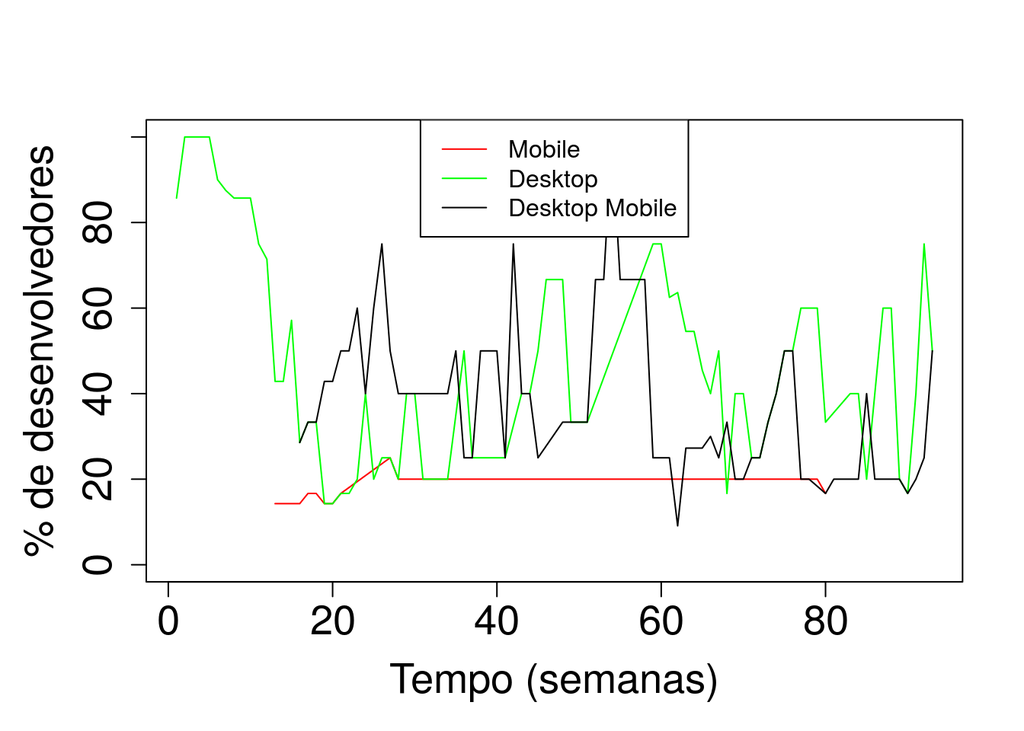

|  | mobile | desktop | mobiledesktop |
| --- | --- | --- | --- |
| twosided | 0.0074055 | 0.2144143 | 0.0000018 |
| greater | 0.0037028 | 0.8927928 | 0.9999991 |
| less | 0.9962972 | 0.1072072 | 0.0000009 |

#### Allegro

0.2 [1] “

"

#### Evolução dos desenvolvedores ao longo do tempo (Desktop Mobile)

( janela 24 semanas, iteracao de 4 semanas) [1] “

"

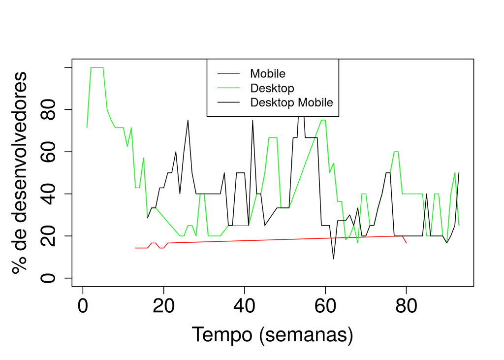

|  | mobile | desktop | mobiledesktop |
| --- | --- | --- | --- |
| twosided | 0.0420594 | 0.0046051 | 0.0000155 |
| greater | 0.0210297 | 0.9976974 | 0.9999923 |
| less | 0.9789703 | 0.0023026 | 0.0000077 |

#### Allegro

0.3 [1] “

"

#### Evolução dos desenvolvedores ao longo do tempo (Desktop Mobile)

( janela 24 semanas, iteracao de 4 semanas) [1] “

"

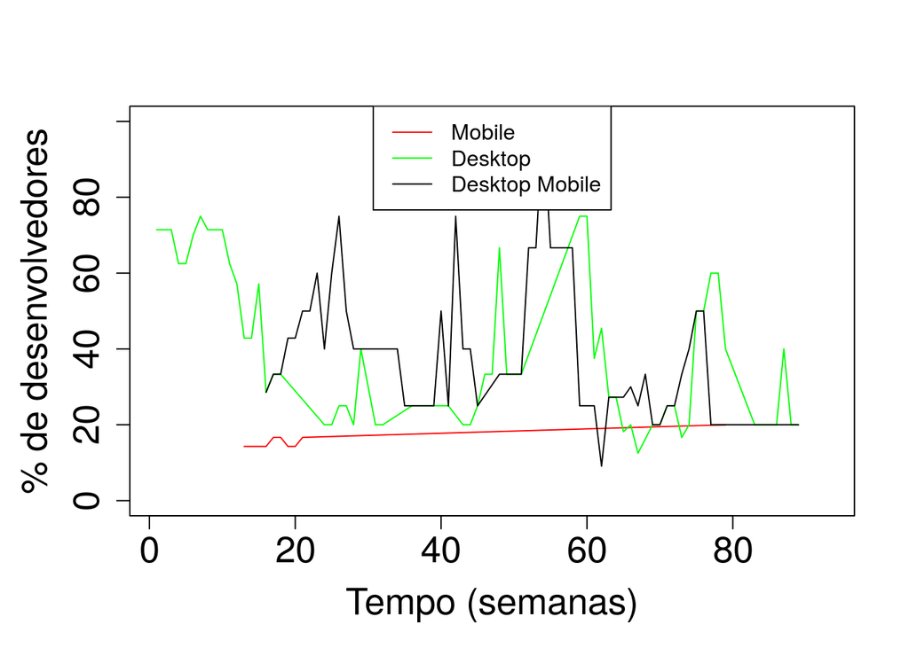

|  | mobile | desktop | mobiledesktop |
| --- | --- | --- | --- |
| twosided | 0.0619696 | 0.0000456 | 0.0002634 |
| greater | 0.0309848 | 0.9999772 | 0.9998683 |
| less | 0.9690152 | 0.0000228 | 0.0001317 |

#### Allegro

0.4 [1] “

"

#### Evolução dos desenvolvedores ao longo do tempo (Desktop Mobile)

( janela 24 semanas, iteracao de 4 semanas) [1] “

"

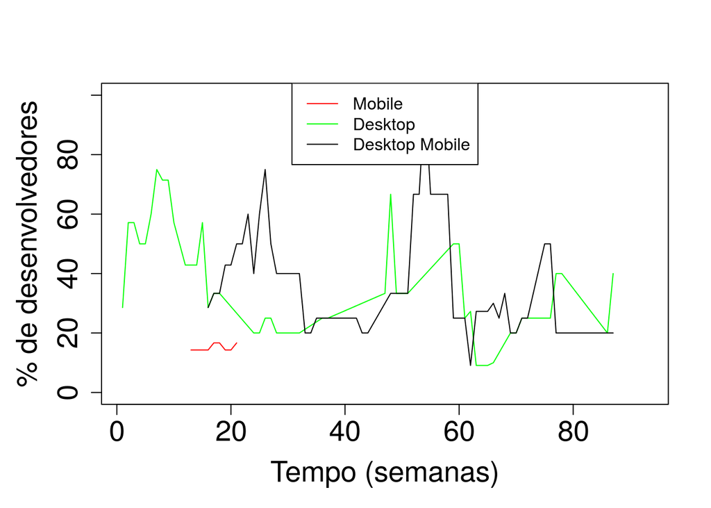

|  | mobile | desktop | mobiledesktop |
| --- | --- | --- | --- |
| twosided | 0.2452781 | 0.0001127 | 0.0051168 |
| greater | 0.1226391 | 0.9999437 | 0.9974416 |
| less | 0.8773609 | 0.0000563 | 0.0025584 |

#### Allegro

0.5 [1] “

"

#### Evolução dos desenvolvedores ao longo do tempo (Desktop Mobile)

( janela 24 semanas, iteracao de 4 semanas) [1] “

"

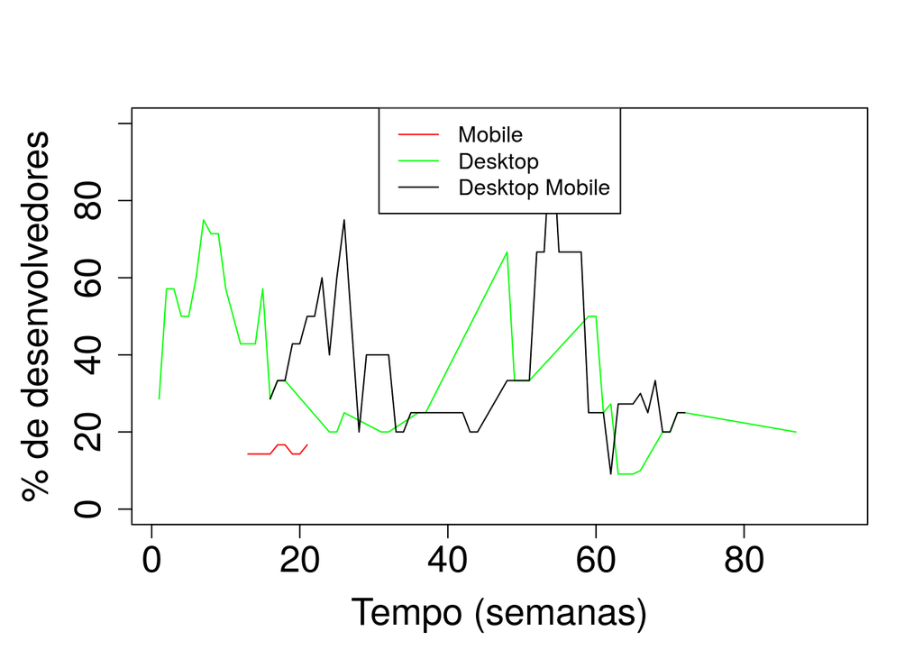

|  | mobile | desktop | mobiledesktop |
| --- | --- | --- | --- |
| twosided | 0.2452781 | 0.0000045 | 0.0718852 |
| greater | 0.1226391 | 0.9999977 | 0.9640574 |
| less | 0.8773609 | 0.0000023 | 0.0359426 |

#### SDL

0.1 [1] “

"

#### Evolução dos desenvolvedores ao longo do tempo (Desktop Mobile)

( janela 24 semanas, iteracao de 4 semanas) [1] “

"

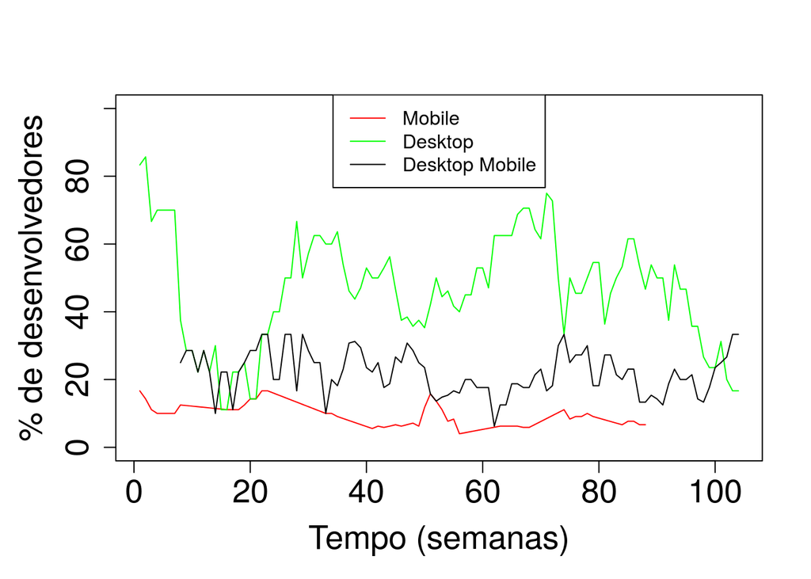

|  | mobile | desktop | mobiledesktop |
| --- | --- | --- | --- |
| twosided | 0.0007683 | 0.8023586 | 0.0401992 |
| greater | 0.9996159 | 0.5988207 | 0.9799004 |
| less | 0.0003841 | 0.4011793 | 0.0200996 |

#### SDL

0.2 [1] “

"

#### Evolução dos desenvolvedores ao longo do tempo (Desktop Mobile)

( janela 24 semanas, iteracao de 4 semanas) [1] “

"

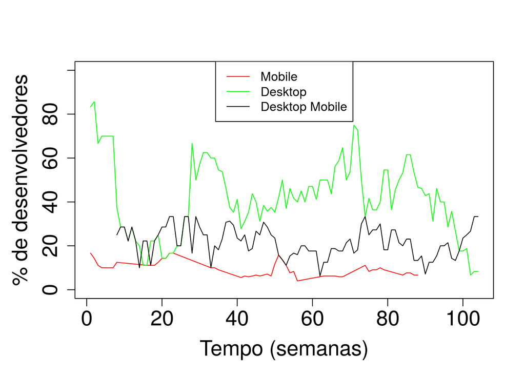

|  | mobile | desktop | mobiledesktop |
| --- | --- | --- | --- |
| twosided | 0.0007683 | 0.9484566 | 0.0177803 |
| greater | 0.9996159 | 0.5257717 | 0.9911099 |
| less | 0.0003841 | 0.4742283 | 0.0088901 |

#### SDL

0.3 [1] “

"

#### Evolução dos desenvolvedores ao longo do tempo (Desktop Mobile)

( janela 24 semanas, iteracao de 4 semanas) [1] “

"

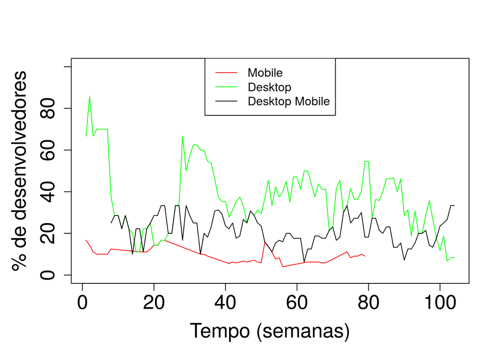

|  | mobile | desktop | mobiledesktop |
| --- | --- | --- | --- |
| twosided | 0.0019977 | 0.0528204 | 0.0177803 |
| greater | 0.9990012 | 0.9735898 | 0.9911099 |
| less | 0.0009988 | 0.0264102 | 0.0088901 |

#### SDL

0.4 [1] “

"

#### Evolução dos desenvolvedores ao longo do tempo (Desktop Mobile)

( janela 24 semanas, iteracao de 4 semanas) [1] “

"

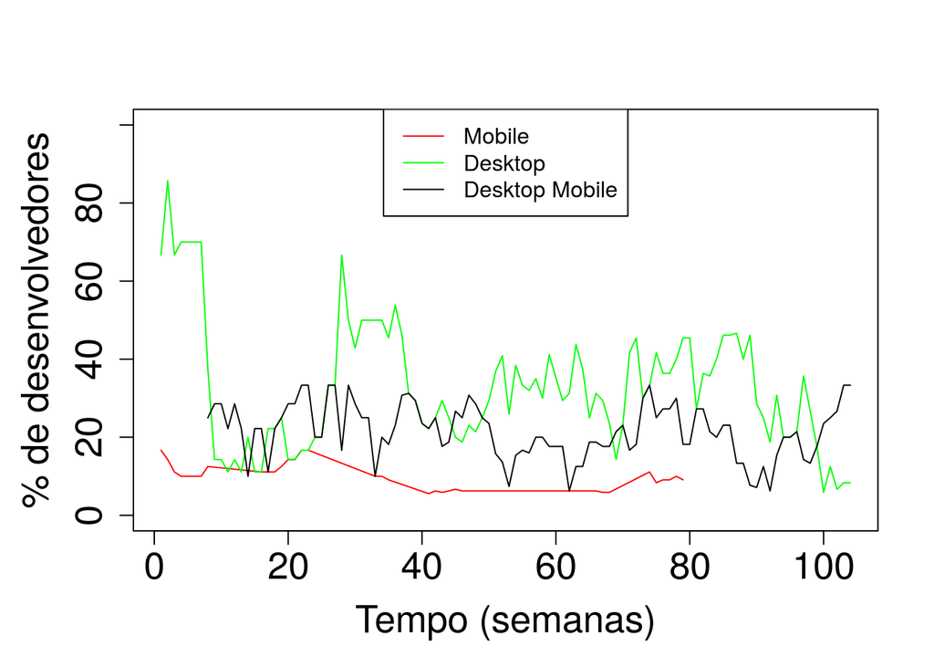

|  | mobile | desktop | mobiledesktop |
| --- | --- | --- | --- |
| twosided | 0.0013136 | 0.4263407 | 0.0138693 |
| greater | 0.9993432 | 0.7868297 | 0.9930653 |
| less | 0.0006568 | 0.2131703 | 0.0069347 |

#### SDL

0.5 [1] “

"

#### Evolução dos desenvolvedores ao longo do tempo (Desktop Mobile)

( janela 24 semanas, iteracao de 4 semanas) [1] “

"

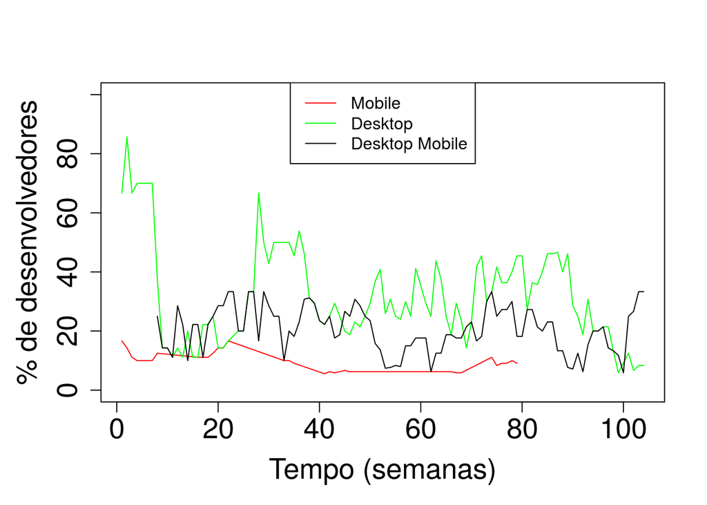

|  | mobile | desktop | mobiledesktop |
| --- | --- | --- | --- |
| twosided | 0.0012030 | 0.2241224 | 0.0664639 |
| greater | 0.9993985 | 0.8879388 | 0.9667680 |
| less | 0.0006015 | 0.1120612 | 0.0332320 |

#### SFML

0.1 [1] “

"

#### Evolução dos desenvolvedores ao longo do tempo (Desktop Mobile)

( janela 24 semanas, iteracao de 4 semanas) [1] “

"

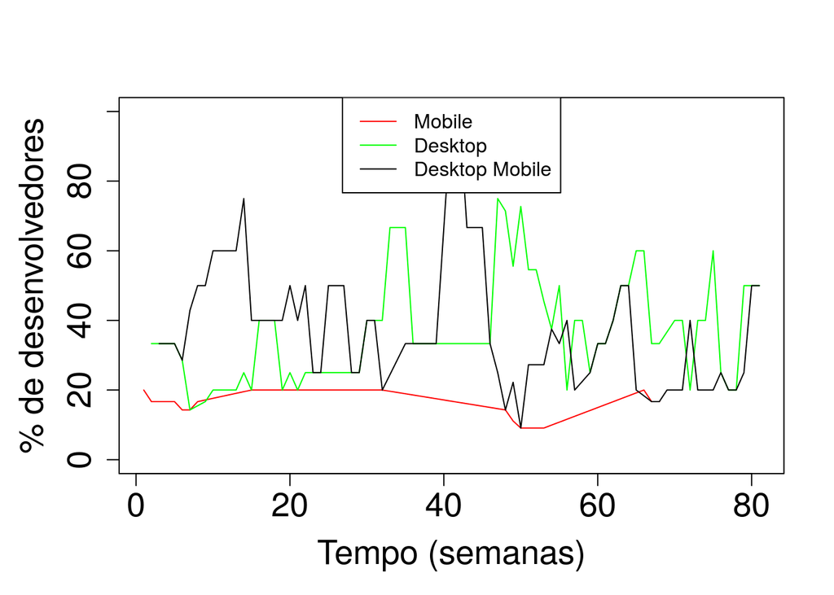

|  | mobile | desktop | mobiledesktop |
| --- | --- | --- | --- |
| twosided | 0.1481111 | 0.000574 | 0.0001441 |
| greater | 0.9259445 | 0.000287 | 0.9999279 |
| less | 0.0740555 | 0.999713 | 0.0000721 |

#### SFML

0.2 [1] “

"

#### Evolução dos desenvolvedores ao longo do tempo (Desktop Mobile)

( janela 24 semanas, iteracao de 4 semanas) [1] “

"

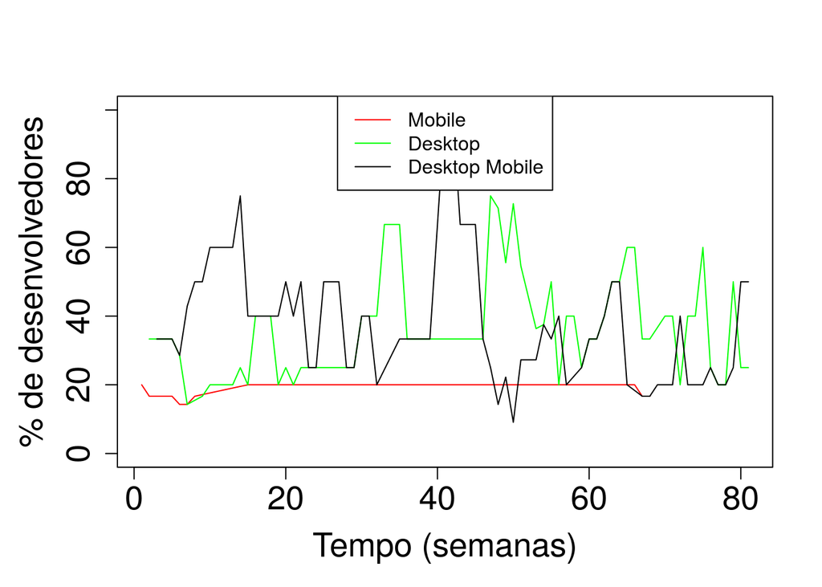

|  | mobile | desktop | mobiledesktop |
| --- | --- | --- | --- |
| twosided | 0.4773201 | 0.0056258 | 0.0001441 |
| greater | 0.2386600 | 0.0028129 | 0.9999279 |
| less | 0.7613400 | 0.9971871 | 0.0000721 |

#### SFML

0.3 [1] “

"

#### Evolução dos desenvolvedores ao longo do tempo (Desktop Mobile)

( janela 24 semanas, iteracao de 4 semanas) [1] “

"

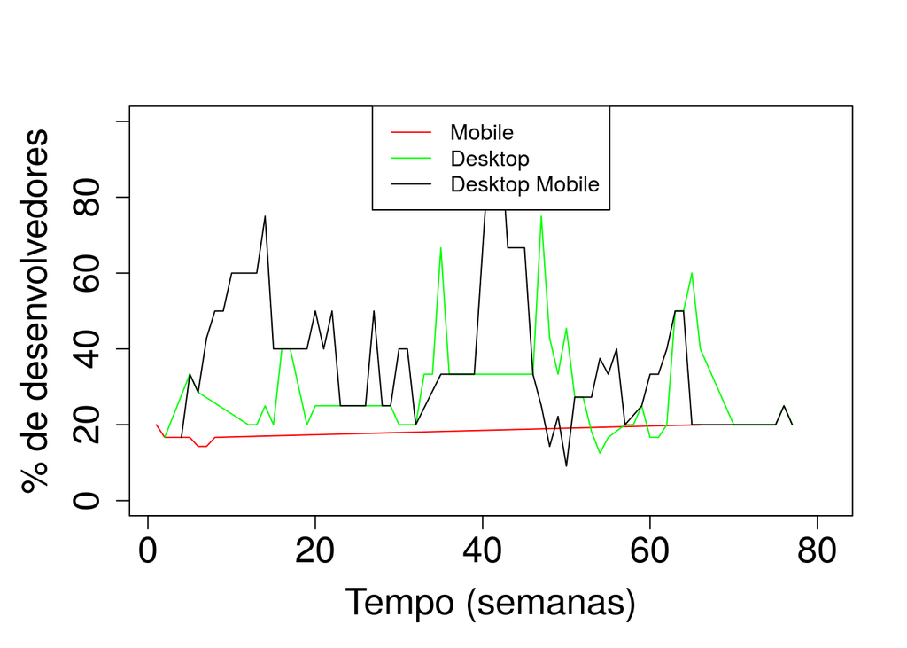

|  | mobile | desktop | mobiledesktop |
| --- | --- | --- | --- |
| twosided | 0.5593049 | 0.5775585 | 0.002596 |
| greater | 0.7203475 | 0.7112207 | 0.998702 |
| less | 0.2796525 | 0.2887793 | 0.001298 |

#### SFML

0.4 [1] “

"

#### Evolução dos desenvolvedores ao longo do tempo (Desktop Mobile)

( janela 24 semanas, iteracao de 4 semanas) [1] “

"

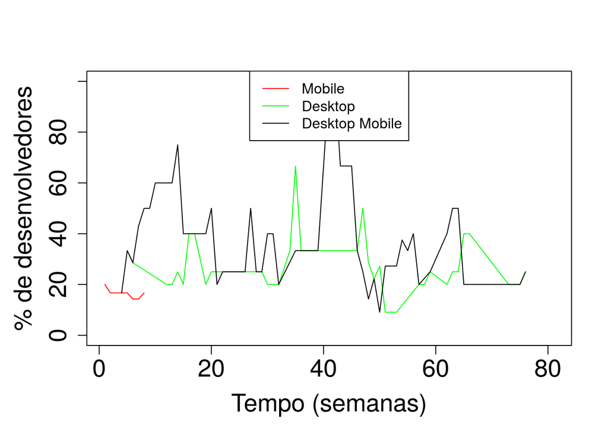

|  | mobile | desktop | mobiledesktop |
| --- | --- | --- | --- |
| twosided | 0.0821938 | 0.4122746 | 0.0153917 |
| greater | 0.9589031 | 0.7938627 | 0.9923041 |
| less | 0.0410969 | 0.2061373 | 0.0076959 |

#### SFML

0.5 [1] “

"

#### Evolução dos desenvolvedores ao longo do tempo (Desktop Mobile)

( janela 24 semanas, iteracao de 4 semanas) [1] “

"

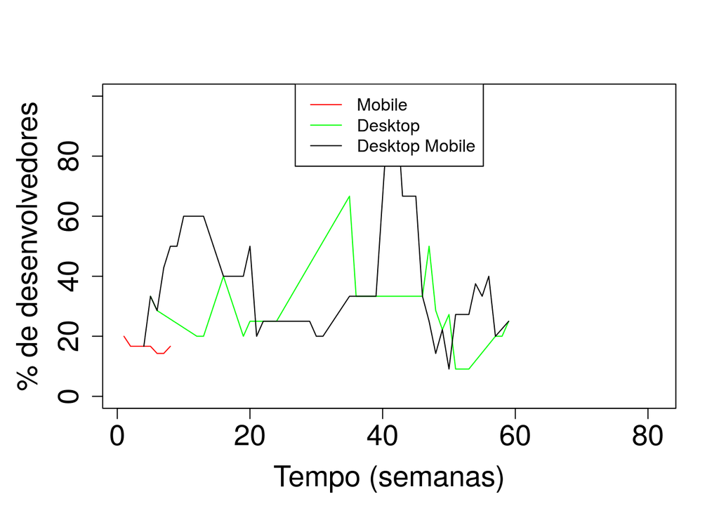

|  | mobile | desktop | mobiledesktop |
| --- | --- | --- | --- |
| twosided | 0.0821938 | 0.1544065 | 0.1836639 |
| greater | 0.9589031 | 0.9227967 | 0.9081680 |
| less | 0.0410969 | 0.0772033 | 0.0918320 |

#### Coco2dx

0.1 [1] “

"

#### Evolução dos desenvolvedores ao longo do tempo (Desktop Mobile)

( janela 24 semanas, iteracao de 4 semanas) [1] “

"

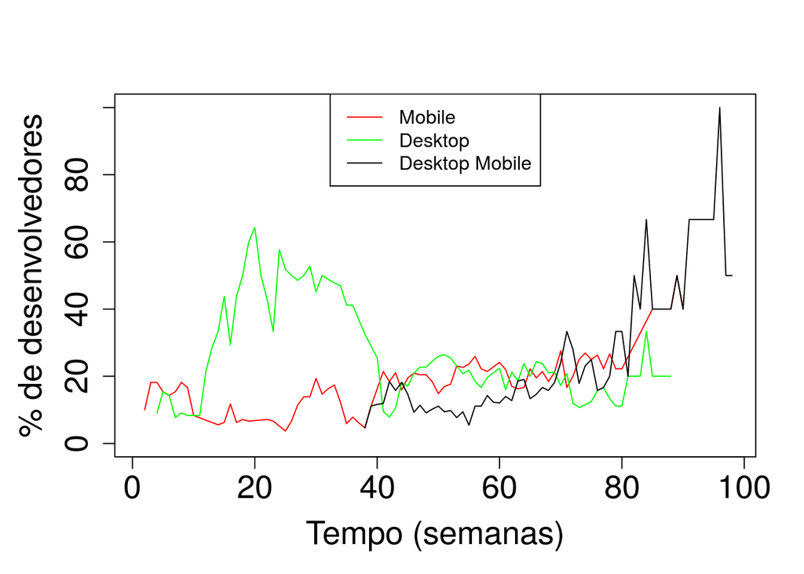

|  | mobile | desktop | mobiledesktop |
| --- | --- | --- | --- |
| twosided | 0 | 0.0002634 | 0 |
| greater | 0 | 0.9998683 | 0 |
| less | 1 | 0.0001317 | 1 |

#### Coco2dx

0.2 [1] “

"

#### Evolução dos desenvolvedores ao longo do tempo (Desktop Mobile)

( janela 24 semanas, iteracao de 4 semanas) [1] “

"

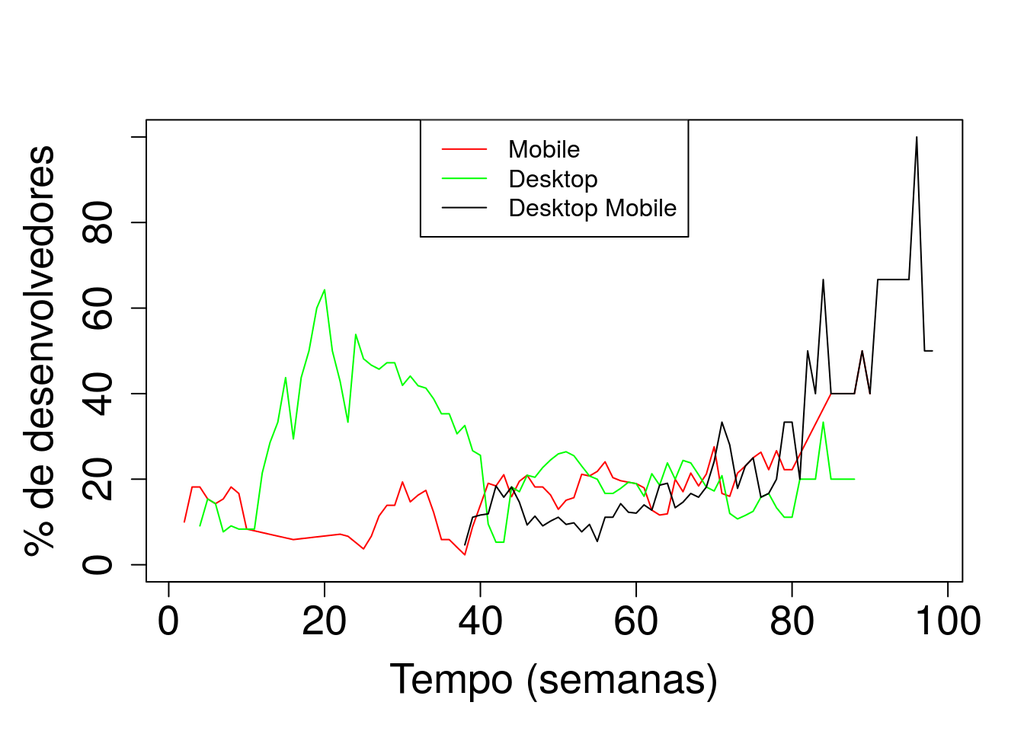

|  | mobile | desktop | mobiledesktop |
| --- | --- | --- | --- |
| twosided | 0 | 0.0001541 | 0 |
| greater | 0 | 0.9999230 | 0 |
| less | 1 | 0.0000770 | 1 |

#### Coco2dx

0.3 [1] “

"

#### Evolução dos desenvolvedores ao longo do tempo (Desktop Mobile)

( janela 24 semanas, iteracao de 4 semanas) [1] “

"

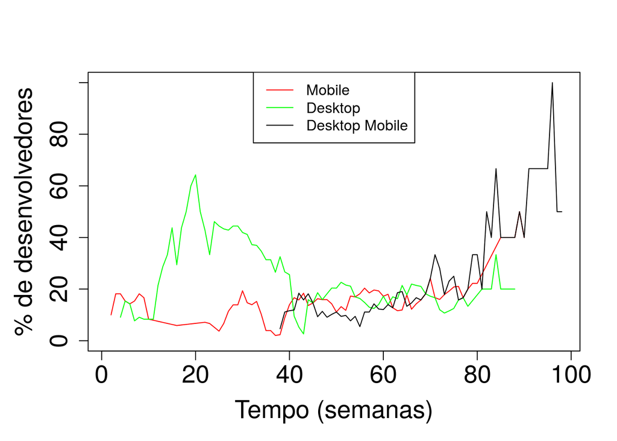

|  | mobile | desktop | mobiledesktop |
| --- | --- | --- | --- |
| twosided | 0 | 0.0022379 | 0 |
| greater | 0 | 0.9988811 | 0 |
| less | 1 | 0.0011189 | 1 |

#### Coco2dx

0.4 [1] “

"

#### Evolução dos desenvolvedores ao longo do tempo (Desktop Mobile)

( janela 24 semanas, iteracao de 4 semanas) [1] “

"

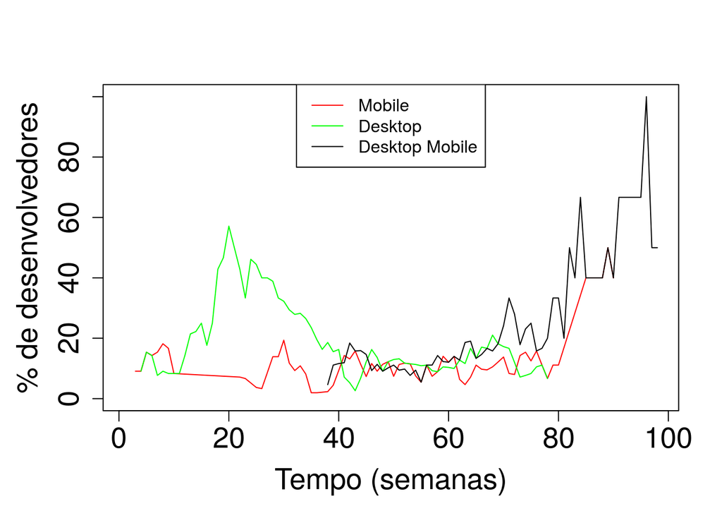

|  | mobile | desktop | mobiledesktop |
| --- | --- | --- | --- |
| twosided | 0.0383382 | 0.0003979 | 0 |
| greater | 0.0191691 | 0.9998010 | 0 |
| less | 0.9808309 | 0.0001990 | 1 |

#### Coco2dx

0.5 [1] “

"

#### Evolução dos desenvolvedores ao longo do tempo (Desktop Mobile)

( janela 24 semanas, iteracao de 4 semanas) [1] “

"

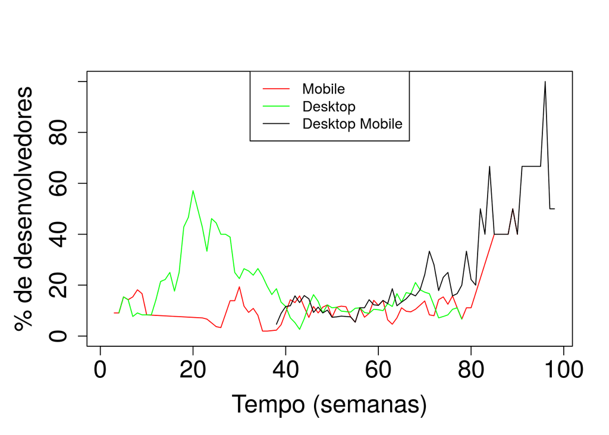

|  | mobile | desktop | mobiledesktop |
| --- | --- | --- | --- |
| twosided | 0.0383382 | 0.0011221 | 0 |
| greater | 0.0191691 | 0.9994389 | 0 |
| less | 0.9808309 | 0.0005611 | 1 |

#### Godot

0.1 [1] “

"

#### Evolução dos desenvolvedores ao longo do tempo (Desktop Mobile)

( janela 24 semanas, iteracao de 4 semanas) [1] “

"

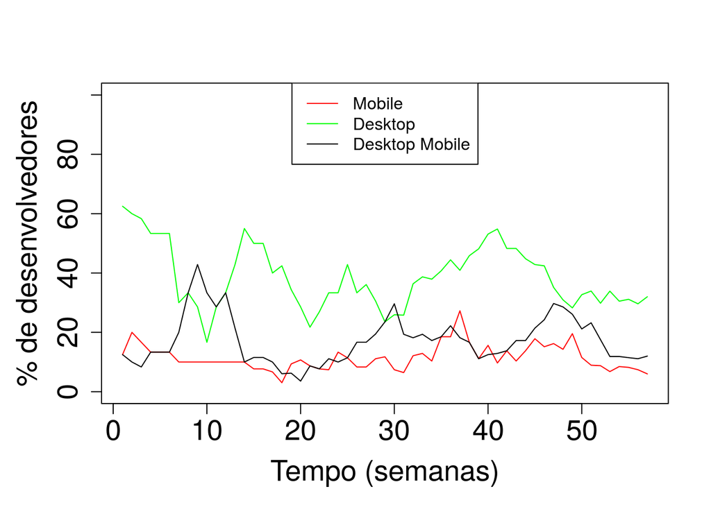

|  | mobile | desktop | mobiledesktop |
| --- | --- | --- | --- |
| twosided | 0.8900962 | 0.0837907 | 0.3111834 |
| greater | 0.5549519 | 0.9581047 | 0.1555917 |
| less | 0.4450481 | 0.0418953 | 0.8444083 |

#### Godot

0.2 [1] “

"

#### Evolução dos desenvolvedores ao longo do tempo (Desktop Mobile)

( janela 24 semanas, iteracao de 4 semanas) [1] “

"

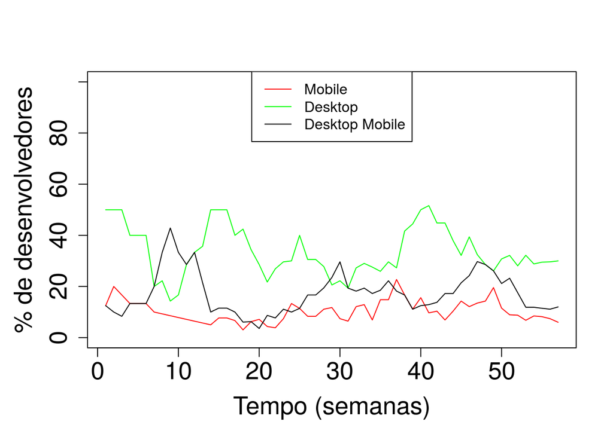

|  | mobile | desktop | mobiledesktop |
| --- | --- | --- | --- |
| twosided | 0.9611045 | 0.4001728 | 0.3111834 |
| greater | 0.4805523 | 0.7999136 | 0.1555917 |
| less | 0.5194477 | 0.2000864 | 0.8444083 |

#### Godot

0.3 [1] “

"

#### Evolução dos desenvolvedores ao longo do tempo (Desktop Mobile)

( janela 24 semanas, iteracao de 4 semanas) [1] “

"

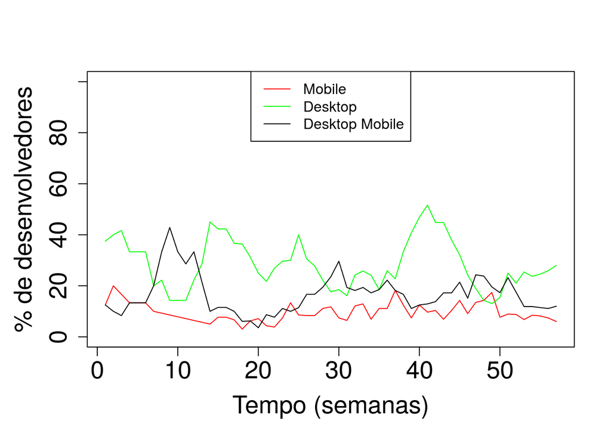

|  | mobile | desktop | mobiledesktop |
| --- | --- | --- | --- |
| twosided | 0.7635343 | 0.1131851 | 0.5172512 |
| greater | 0.6182328 | 0.9434075 | 0.2586256 |
| less | 0.3817672 | 0.0565925 | 0.7413744 |

#### Godot

0.4 [1] “

"

#### Evolução dos desenvolvedores ao longo do tempo (Desktop Mobile)

( janela 24 semanas, iteracao de 4 semanas) [1] “

"

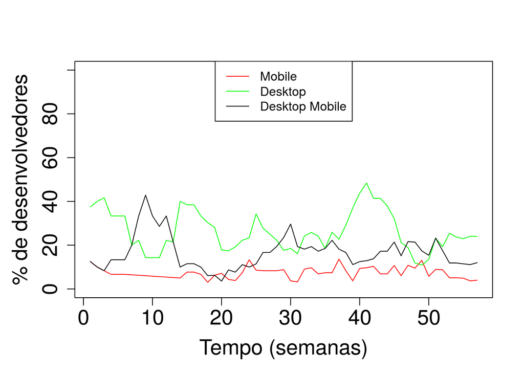

|  | mobile | desktop | mobiledesktop |
| --- | --- | --- | --- |
| twosided | 1.0 | 0.2030654 | 0.6493118 |
| greater | 0.5 | 0.8984673 | 0.3246559 |
| less | 0.5 | 0.1015327 | 0.6753441 |

#### Godot

0.5 [1] “

"

#### Evolução dos desenvolvedores ao longo do tempo (Desktop Mobile)

( janela 24 semanas, iteracao de 4 semanas) [1] “

"

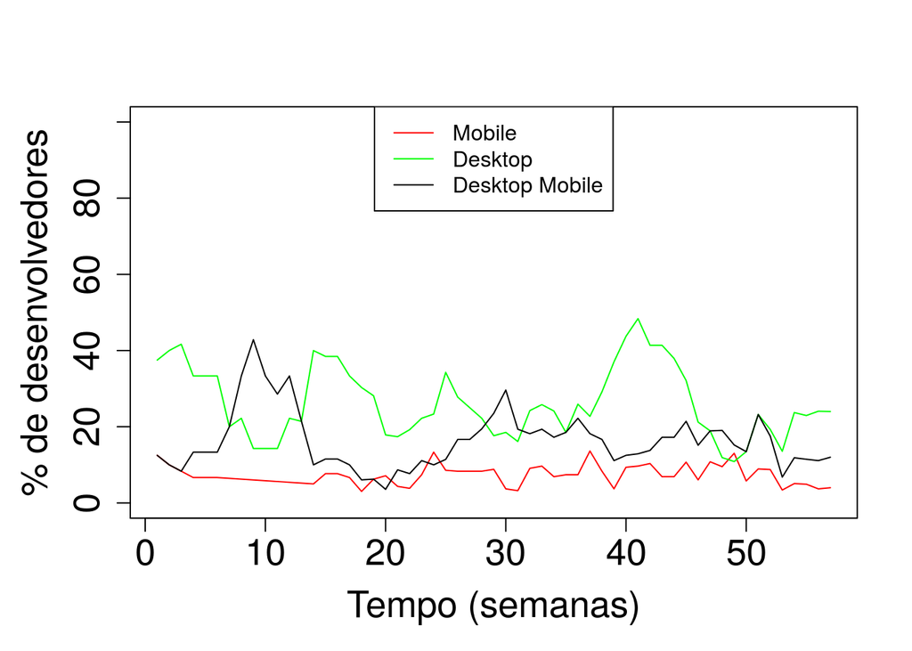

|  | mobile | desktop | mobiledesktop |
| --- | --- | --- | --- |
| twosided | 0.9933169 | 0.1197733 | 0.9395943 |
| greater | 0.5033415 | 0.9401133 | 0.4697971 |
| less | 0.4966585 | 0.0598867 | 0.5302029 |